# Exploratory Data Analysis of Soccer Players Dataset

## Load and Inspect the Dataset

```r
# players <- read.csv("C:/Users/marti/OneDrive/Documents/OZNAL/OZNAL/data/players_22.csv")
players <- read.csv("C:/Users/olko/Desktop/OZNAL/data/players_22.csv")
glimpse(players) # Provides a brief overview of the dataset
```

```
## Rows: 19,239
## Columns: 110
## $ sofifa_id                   <int> 158023, 188545, 20801, 190871, 192985, 200…
## $ player_url                  <chr> "https://sofifa.com/player/158023/lionel-m…
## $ short_name                  <chr> "L. Messi", "R. Lewandowski", "Cristiano R…
## $ long_name                   <chr> "Lionel Andrés Messi Cuccittini", "Robert …
## $ player_positions            <chr> "RW, ST, CF", "ST", "ST, LW", "LW, CAM", "…
## $ overall                     <int> 93, 92, 91, 91, 91, 91, 91, 90, 90, 90, 90…
## $ potential                   <int> 93, 92, 91, 91, 91, 93, 95, 90, 92, 90, 90…
## $ value_eur                   <dbl> 78000000, 119500000, 45000000, 129000000, …
## $ wage_eur                    <dbl> 320000, 270000, 270000, 270000, 350000, 13…
## $ age                         <int> 34, 32, 36, 29, 30, 28, 22, 35, 29, 27, 30…
## $ dob                         <chr> "1987-06-24", "1988-08-21", "1985-02-05", …
## $ height_cm                   <int> 170, 185, 187, 175, 181, 188, 182, 193, 18…
## $ weight_kg                   <int> 72, 81, 83, 68, 70, 87, 73, 93, 85, 89, 70…
```

[output cut: 97 more lines]

```r
summary(players) # Summarizes the data giving quick insights
```

```
##    sofifa_id       player_url         short_name         long_name
##  Min.   :    41   Length:19239       Length:19239       Length:19239
##  1st Qu.:214414   Class :character   Class :character   Class :character
##  Median :236543   Mode  :character   Mode  :character   Mode  :character
##  Mean   :231468
##  3rd Qu.:253533
##  Max.   :264640
##
##  player_positions      overall        potential       value_eur
##  Length:19239       Min.   :47.00   Min.   :49.00   Min.   :9.00e+03
##  Class :character   1st Qu.:61.00   1st Qu.:67.00   1st Qu.:4.75e+05
##  Mode  :character   Median :66.00   Median :71.00   Median :9.75e+05
##                     Mean   :65.77   Mean   :71.08   Mean   :2.85e+06
##                     3rd Qu.:70.00   3rd Qu.:75.00   3rd Qu.:2.00e+06
##                     Max.   :93.00   Max.   :95.00   Max.   :1.94e+08
##                                                     NA's   :74
##     wage_eur           age            dob              height_cm
##  Min.   :   500   Min.   :16.00   Length:19239       Min.   :155.0
##  1st Qu.:  1000   1st Qu.:21.00   Class :character   1st Qu.:176.0
##  Median :  3000   Median :25.00   Mode  :character   Median :181.0
##  Mean   :  9018   Mean   :25.21                      Mean   :181.3
##  3rd Qu.:  8000   3rd Qu.:29.00                      3rd Qu.:186.0
##  Max.   :350000   Max.   :54.00                      Max.   :206.0
##  NA's   :61
##    weight_kg       club_team_id     club_name         league_name
##  Min.   : 49.00   Min.   :     1   Length:19239       Length:19239
##  1st Qu.: 70.00   1st Qu.:   479   Class :character   Class :character
##  Median : 75.00   Median :  1938   Mode  :character   Mode  :character
##  Mean   : 74.94   Mean   : 50581
##  3rd Qu.: 80.00   3rd Qu.:111139
##  Max.   :110.00   Max.   :115820
##                   NA's   :61
##   league_level   club_position      club_jersey_number club_loaned_from
##  Min.   :1.000   Length:19239       Min.   : 1.00      Length:19239
##  1st Qu.:1.000   Class :character   1st Qu.: 9.00      Class :character
##  Median :1.000   Mode  :character   Median :18.00      Mode  :character
##  Mean   :1.354                      Mean   :20.95
##  3rd Qu.:1.000                      3rd Qu.:27.00
##  Max.   :5.000                      Max.   :99.00
##  NA's   :61                         NA's   :61
```

[output cut: 177 more lines]

```
##  Length:19239       Length:19239       Length:19239       Length:19239
##  Class :character   Class :character   Class :character   Class :character
##  Mode  :character   Mode  :character   Mode  :character   Mode  :character
##
##
##
##
##  club_logo_url      club_flag_url      nation_logo_url    nation_flag_url
##  Length:19239       Length:19239       Length:19239       Length:19239
##  Class :character   Class :character   Class :character   Class :character
##  Mode  :character   Mode  :character   Mode  :character   Mode  :character
##
##
##
##
```

## Data Cleaning

Remove players, that play as a goalkeeper

```r
players <- players %>%
  filter(!str_detect(player_positions, "GK"))
```

Visualize relationships between variables

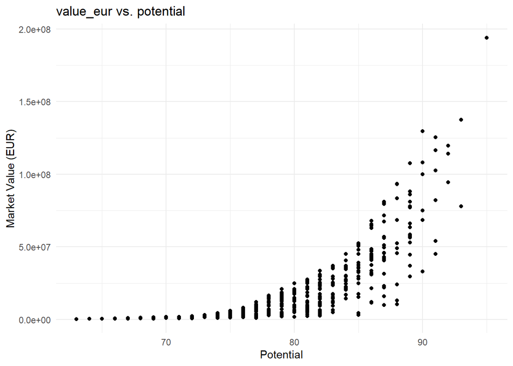

```r
# Selecting specific columns for the pair plot
selected_columns <- players[, c("value_eur", "potential", "overall", "age", "wage_eur", "height_cm", "weight_kg", "league_level", "club_contract_valid_until", "nation_team_id", "release_clause_eur", "skill_moves", "pace", "shooting", "passing", "dribbling", "defending", "physic")]

# Removing rows with NA values to ensure the plot works correctly
selected_columns_clean <- na.omit(selected_columns)

# Plot value_eur vs potential
ggplot(selected_columns_clean, aes(x = potential, y = value_eur)) +
  geom_point() +
  theme_minimal() +
  labs(title = "value_eur vs. potential", x = "Potential", y = "Market Value (EUR)")
```

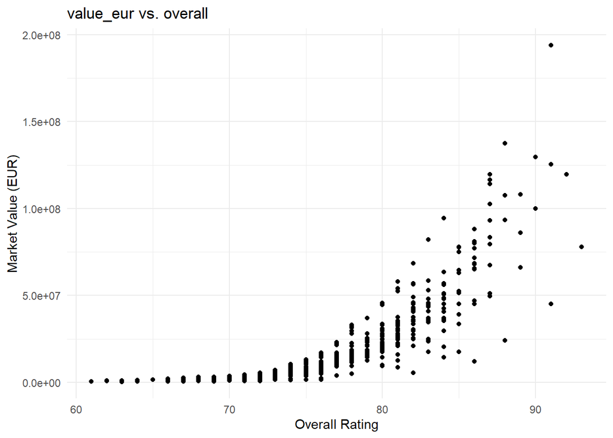

```r
# Plot value_eur vs overall
ggplot(selected_columns_clean, aes(x = overall, y = value_eur)) +
  geom_point() +
  theme_minimal() +
  labs(title = "value_eur vs. overall", x = "Overall Rating", y = "Market Value (EUR)")
```

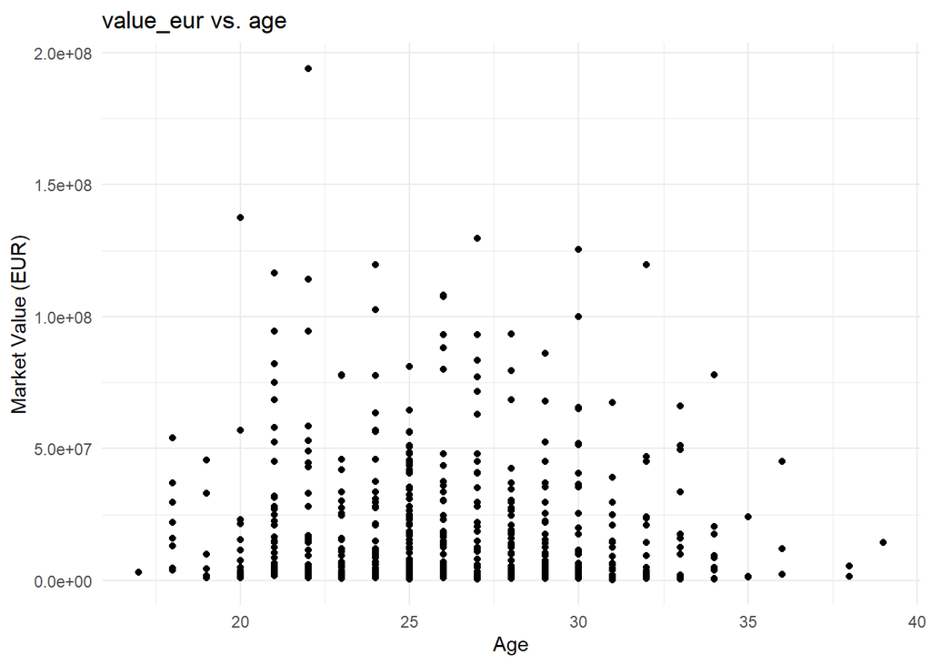

```r
# Plot value_eur vs age
ggplot(selected_columns_clean, aes(x = age, y = value_eur)) +
  geom_point() +
  theme_minimal() +
  labs(title = "value_eur vs. age", x = "Age", y = "Market Value (EUR)")
```

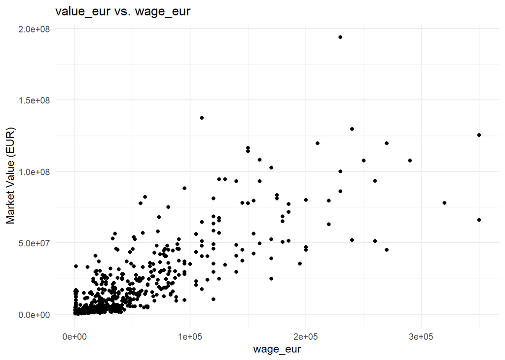

```r
# Plot value_eur vs wage_eur
ggplot(selected_columns_clean, aes(x = wage_eur, y = value_eur)) +
  geom_point() +
  theme_minimal() +
  labs(title = "value_eur vs. wage_eur", x = "wage_eur", y = "Market Value (EUR)")
```

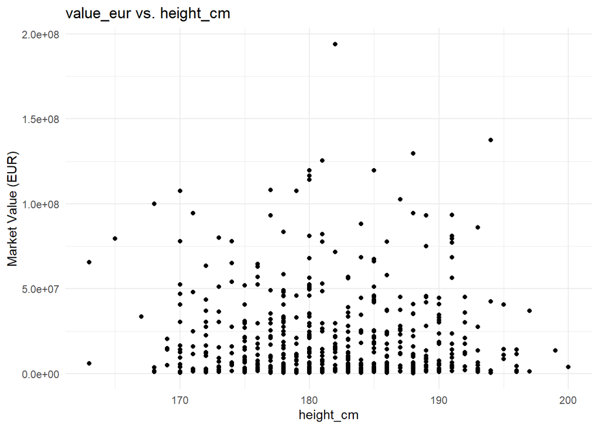

```r
# Plot value_eur vs height_cm
ggplot(selected_columns_clean, aes(x = height_cm, y = value_eur)) +
  geom_point() +
  theme_minimal() +
  labs(title = "value_eur vs. height_cm", x = "height_cm", y = "Market Value (EUR)")
```

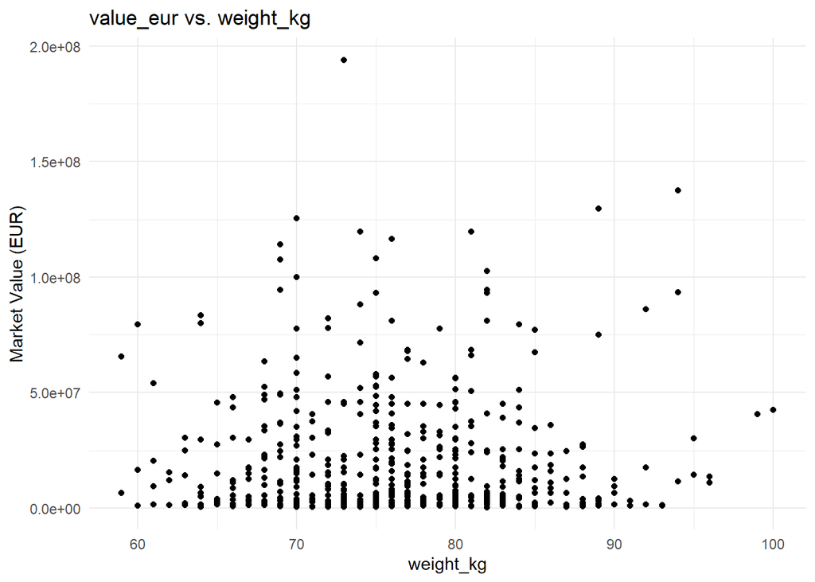

```r
# Plot value_eur vs weight_kg
ggplot(selected_columns_clean, aes(x = weight_kg, y = value_eur)) +
  geom_point() +
  theme_minimal() +
  labs(title = "value_eur vs. weight_kg", x = "weight_kg", y = "Market Value (EUR)")
```

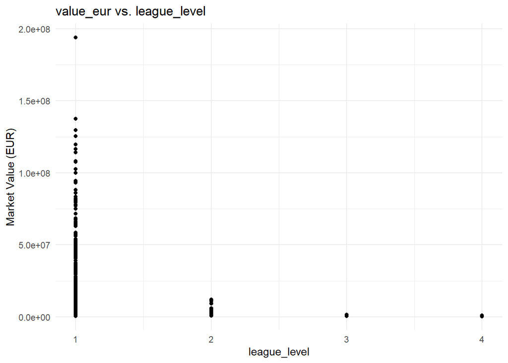

```r
# Plot value_eur vs league_level
ggplot(selected_columns_clean, aes(x = league_level, y = value_eur)) +
  geom_point() +
  theme_minimal() +
  labs(title = "value_eur vs. league_level", x = "league_level", y = "Market Value (EUR)")
```

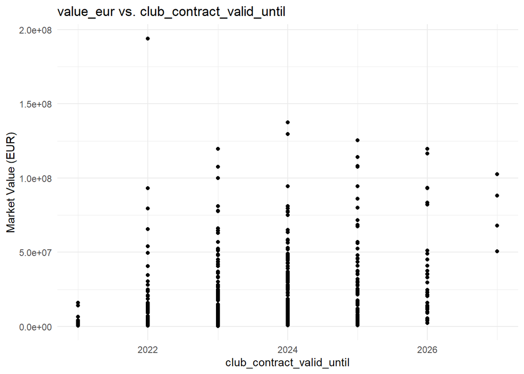

```r
# Plot value_eur vs club_contract_valid_until
ggplot(selected_columns_clean, aes(x = club_contract_valid_until, y = value_eur)) +
  geom_point() +
  theme_minimal() +
  labs(title = "value_eur vs. club_contract_valid_until", x = "club_contract_valid_until", y = "Market Value (EUR)")
```

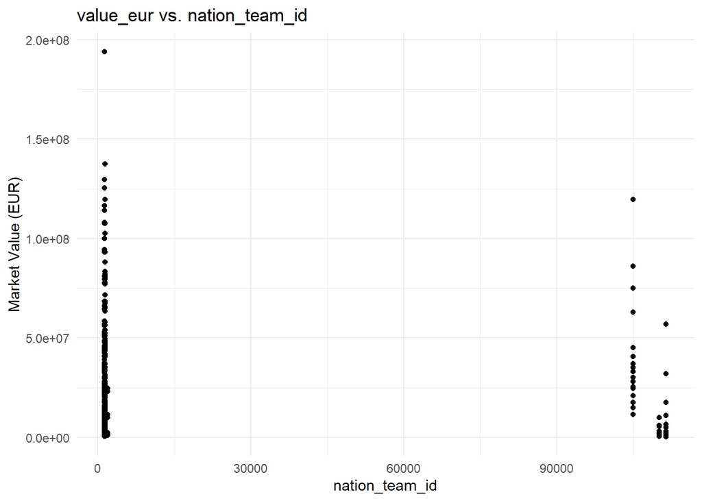

```r
# Plot value_eur vs nation_team_id
ggplot(selected_columns_clean, aes(x = nation_team_id, y = value_eur)) +
  geom_point() +
  theme_minimal() +
  labs(title = "value_eur vs. nation_team_id", x = "nation_team_id", y = "Market Value (EUR)")
```

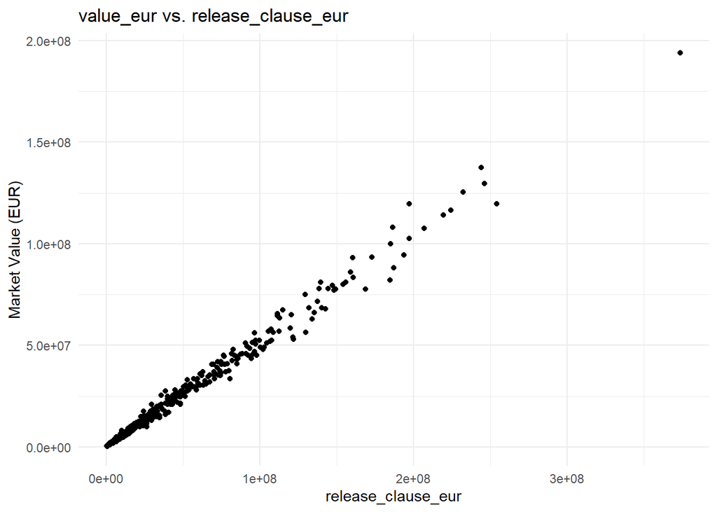

```r
# Plot value_eur vs release_clause_eur
ggplot(selected_columns_clean, aes(x = release_clause_eur, y = value_eur)) +
  geom_point() +
  theme_minimal() +
  labs(title = "value_eur vs. release_clause_eur", x = "release_clause_eur", y = "Market Value (EUR)")
```

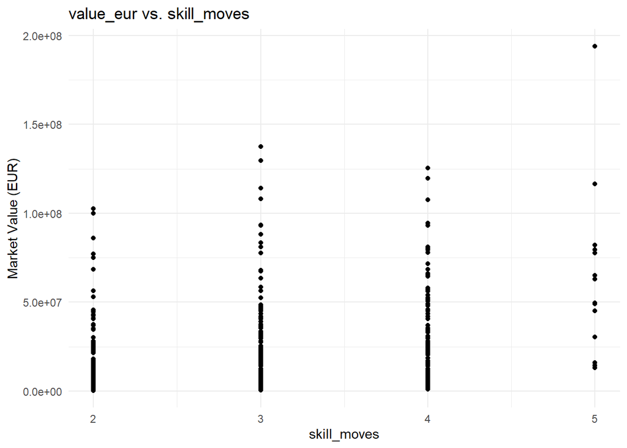

```r
# Plot value_eur vs skill_moves
ggplot(selected_columns_clean, aes(x = skill_moves, y = value_eur)) +
  geom_point() +
  theme_minimal() +
  labs(title = "value_eur vs. skill_moves", x = "skill_moves", y = "Market Value (EUR)")
```

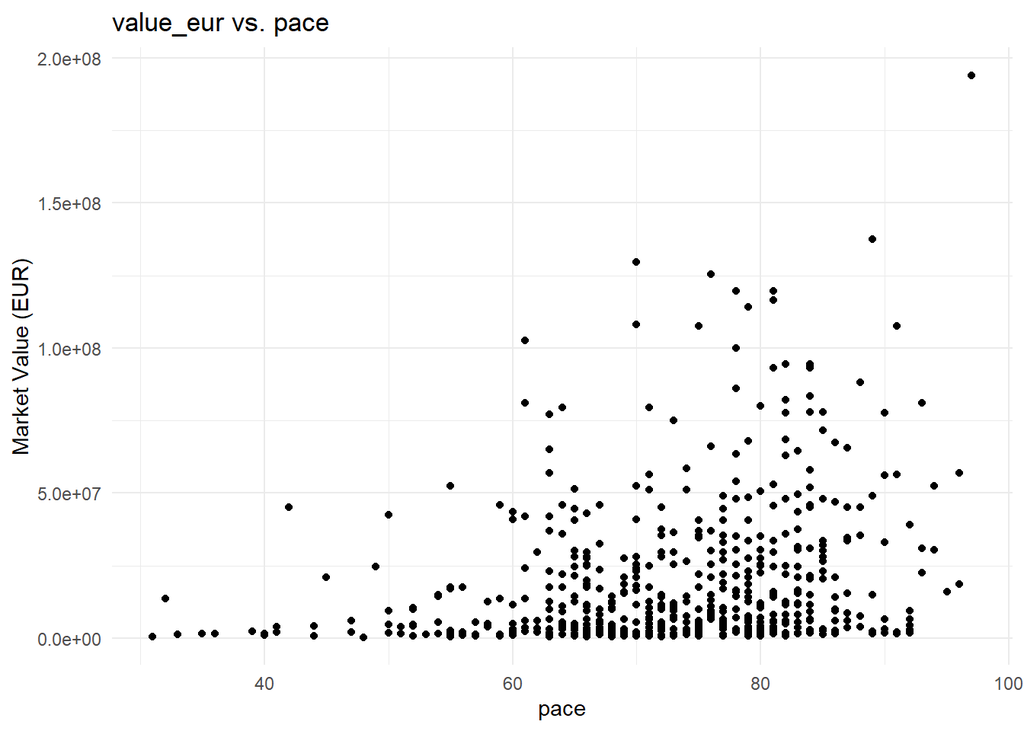

```r
# Plot value_eur vs pace
ggplot(selected_columns_clean, aes(x = pace, y = value_eur)) +
  geom_point() +
  theme_minimal() +
  labs(title = "value_eur vs. pace", x = "pace", y = "Market Value (EUR)")
```

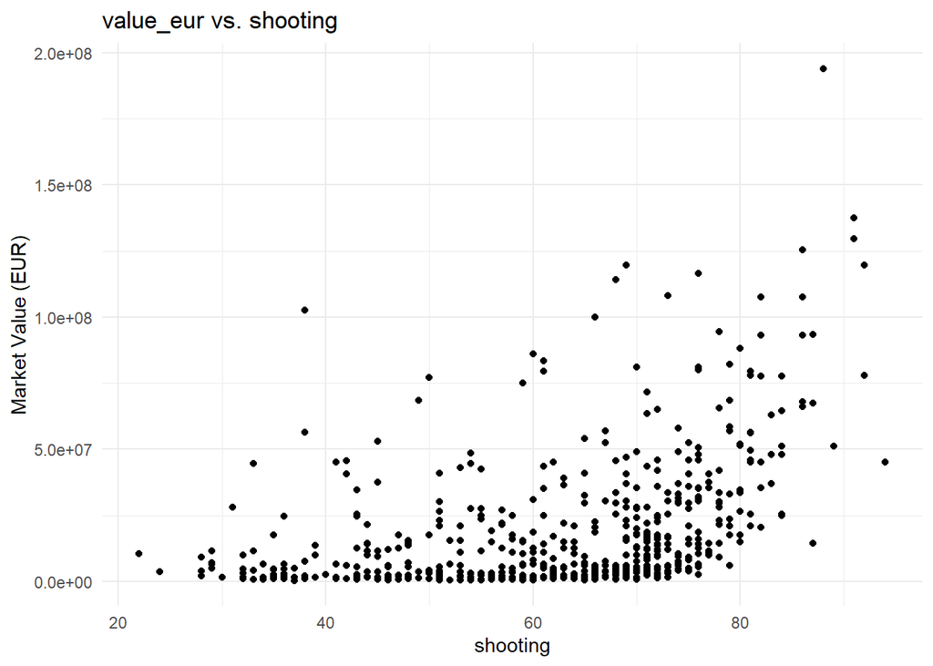

```r
# Plot value_eur vs shooting
ggplot(selected_columns_clean, aes(x = shooting, y = value_eur)) +
  geom_point() +
  theme_minimal() +
  labs(title = "value_eur vs. shooting", x = "shooting", y = "Market Value (EUR)")
```

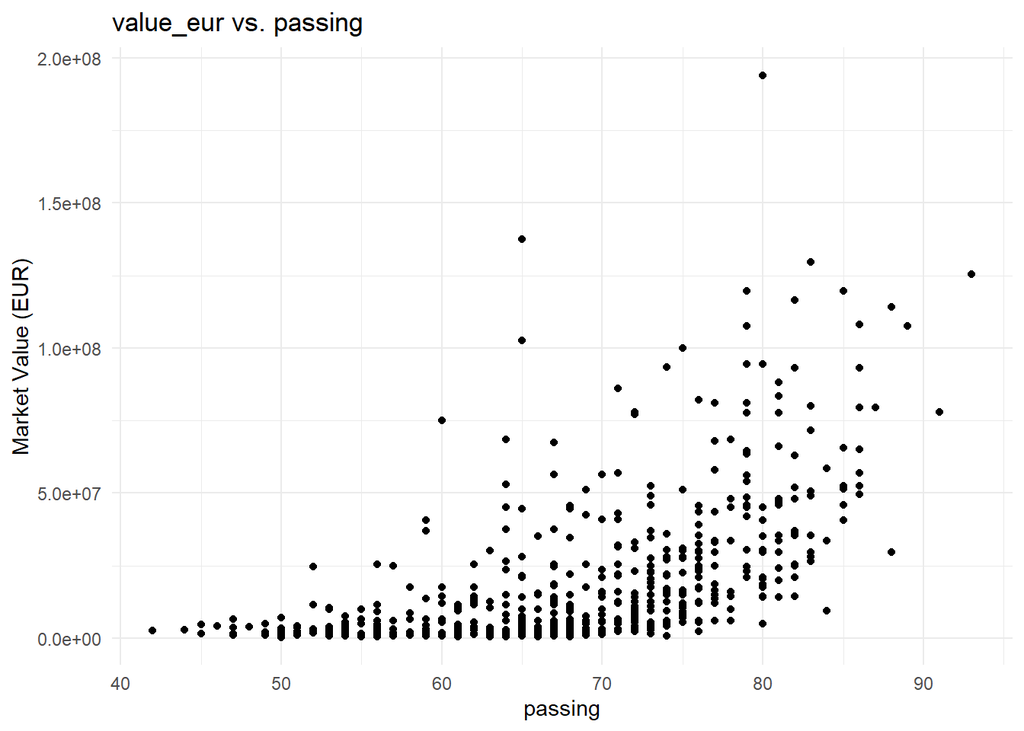

```r
# Plot value_eur vs passing
ggplot(selected_columns_clean, aes(x = passing, y = value_eur)) +
  geom_point() +
  theme_minimal() +
  labs(title = "value_eur vs. passing", x = "passing", y = "Market Value (EUR)")
```

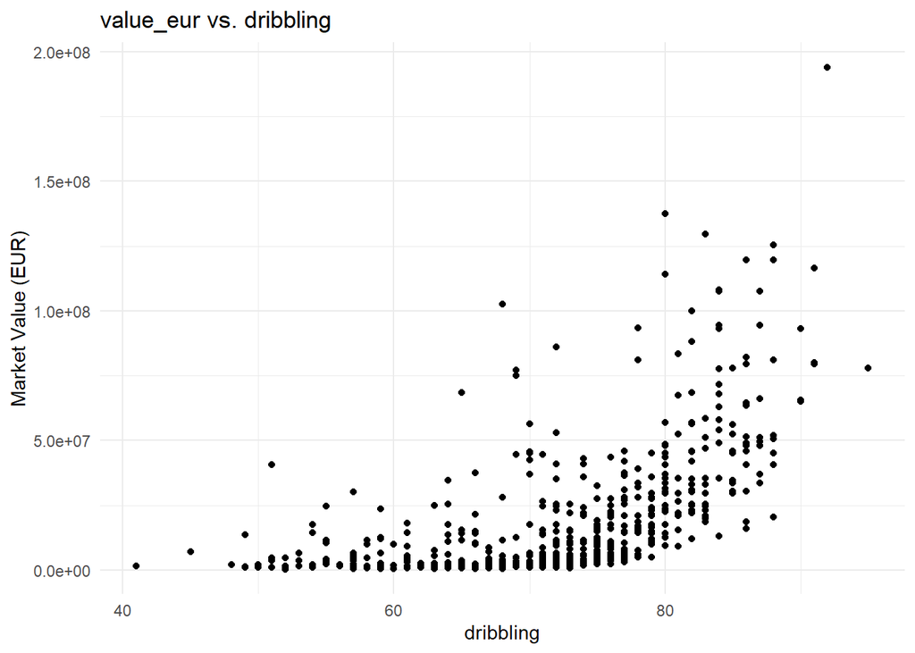

```r
# Plot value_eur vs dribbling
ggplot(selected_columns_clean, aes(x = dribbling, y = value_eur)) +
  geom_point() +
  theme_minimal() +
  labs(title = "value_eur vs. dribbling", x = "dribbling", y = "Market Value (EUR)")
```

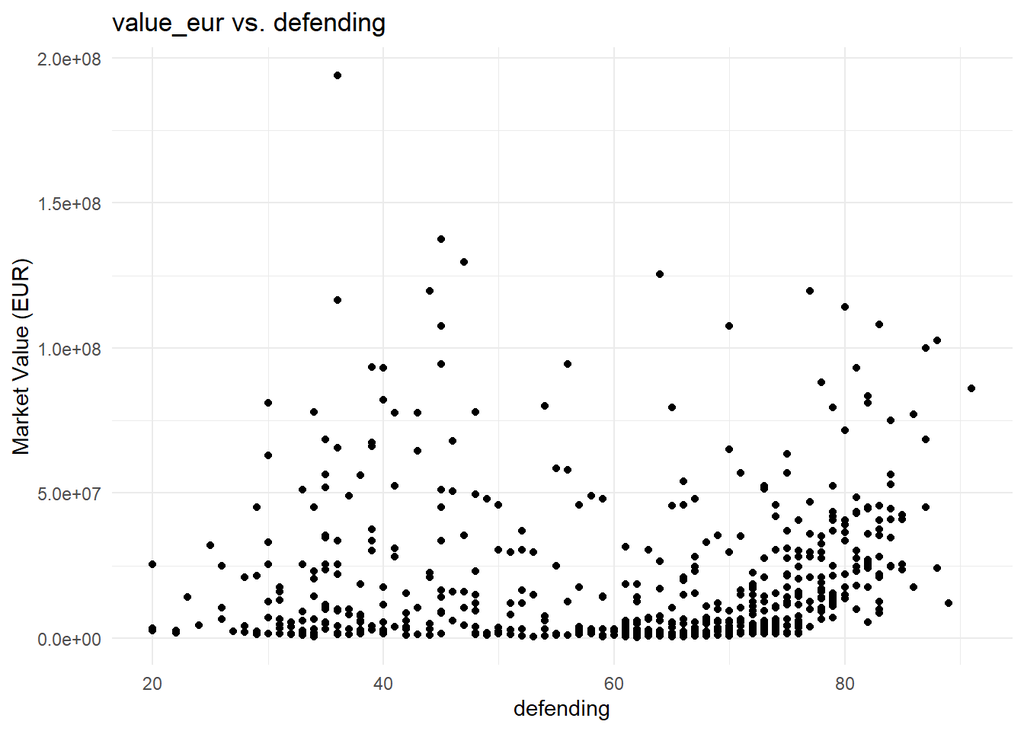

```r
# Plot value_eur vs defending
ggplot(selected_columns_clean, aes(x = defending, y = value_eur)) +
  geom_point() +
  theme_minimal() +
  labs(title = "value_eur vs. defending", x = "defending", y = "Market Value (EUR)")
```

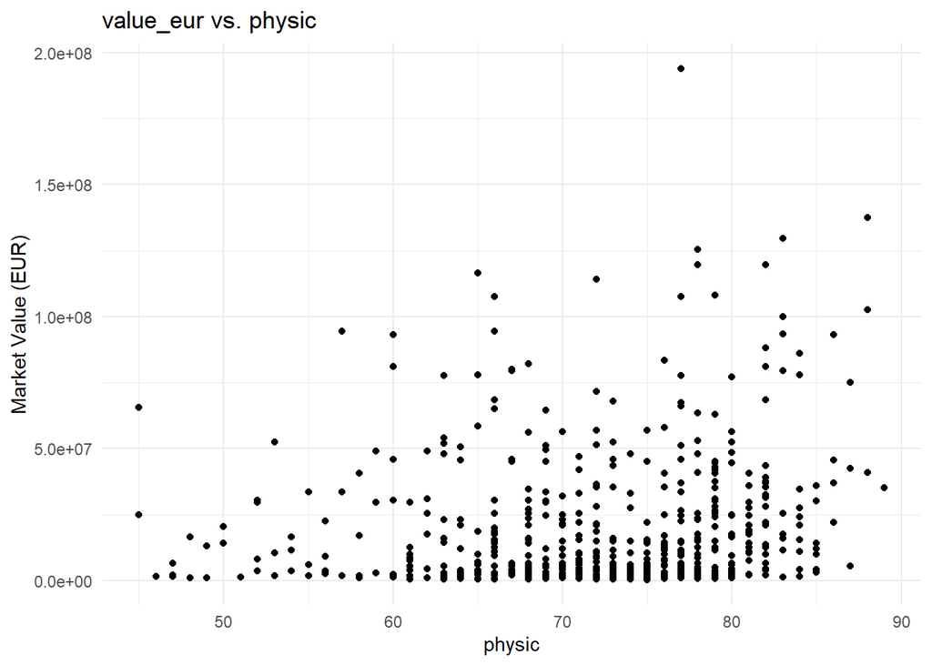

```r
# Plot value_eur vs physic
ggplot(selected_columns_clean, aes(x = physic, y = value_eur)) +
  geom_point() +
  theme_minimal() +
  labs(title = "value_eur vs. physic", x = "physic", y = "Market Value (EUR)")
```

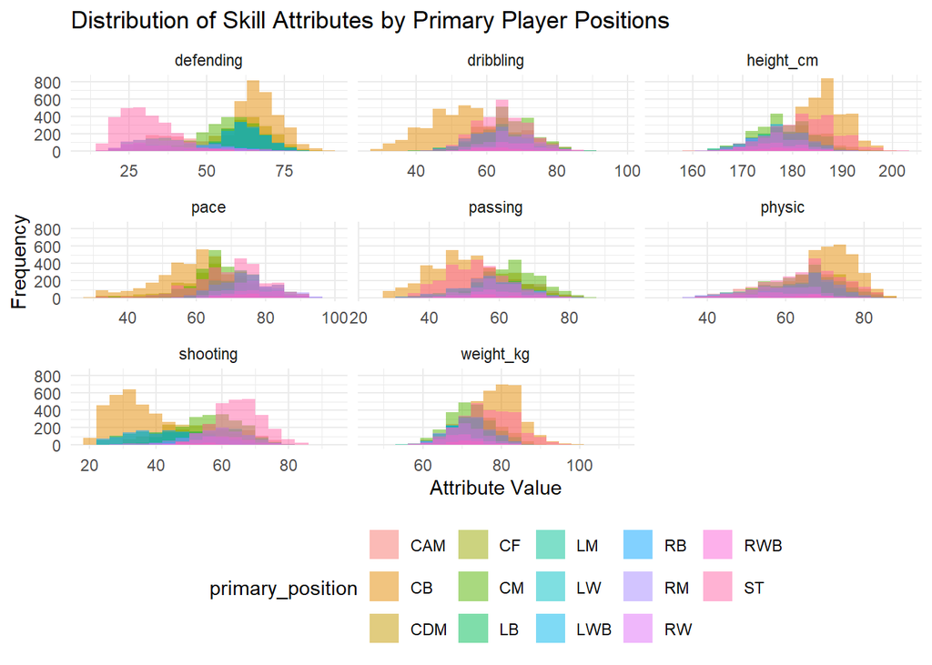

```r
players_simplified <- players %>%
  mutate(primary_position = str_split(player_positions, ",", simplify = TRUE)[,1])

# Histograms for Skill Attributes by Primary Position
players_simplified %>%
  gather(key="skill", value="value", pace, shooting, passing, dribbling, defending, physic, weight_kg, height_cm) %>%
  mutate(skill = factor(skill)) %>%
  ggplot(aes(x=value, fill=primary_position)) +
  geom_histogram(bins=20, alpha=0.5, position="identity") +
  facet_wrap(~skill, scales="free_x") +
  theme_minimal() +
  theme(legend.position="bottom") +
  labs(title="Distribution of Skill Attributes by Primary Player Positions", x="Attribute Value", y="Frequency")
```

Count sum of missing values

```r
count_na_in_column <- function(data, column_name) {
  na_count <- table(is.na(data[[column_name]]))
  print(na_count)
}

count_na_in_column(players, 'overall')
```

```
##
## FALSE
## 17107
```

```r
count_na_in_column(players, 'potential')
```

```
##
## FALSE
## 17107
```

```r
count_na_in_column(players, 'wage_eur')
```

```
##
## FALSE  TRUE
## 17054    53
```

```r
count_na_in_column(players, 'value_eur')
```

```
##
## FALSE  TRUE
## 17041    66
```

```r
count_na_in_column(players, 'player_positions')
```

```
##
## FALSE
## 17107
```

```r
count_na_in_column(players, 'pace')
```

```
##
## FALSE
## 17107
```

```r
count_na_in_column(players, 'shooting')
```

```
##
## FALSE
## 17107
```

```r
count_na_in_column(players, 'passing')
```

```
##
## FALSE
## 17107
```

```r
count_na_in_column(players, 'dribbling')
```

```
##
## FALSE
## 17107
```

```r
count_na_in_column(players, 'defending')
```

```
##
## FALSE
## 17107
```

```r
count_na_in_column(players, 'physic')
```

```
##
## FALSE
## 17107
```

```r
count_na_in_column(players, 'height_cm')
```

```
##
## FALSE
## 17107
```

```r
count_na_in_column(players, 'weight_kg')
```

```
##
## FALSE
## 17107
```

Removing rows with missing values

```r
players <- players %>%
  filter(!is.na(wage_eur))

players <- players %>%
  filter(!is.na(value_eur))
```

Identifying outliers

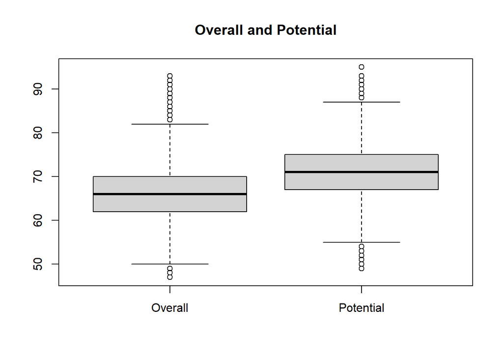

```r
#Boxplots to see if there are any outliers
boxplot(players$overall, players$potential,
        names = c("Overall", "Potential"),
        main = "Overall and Potential")
```

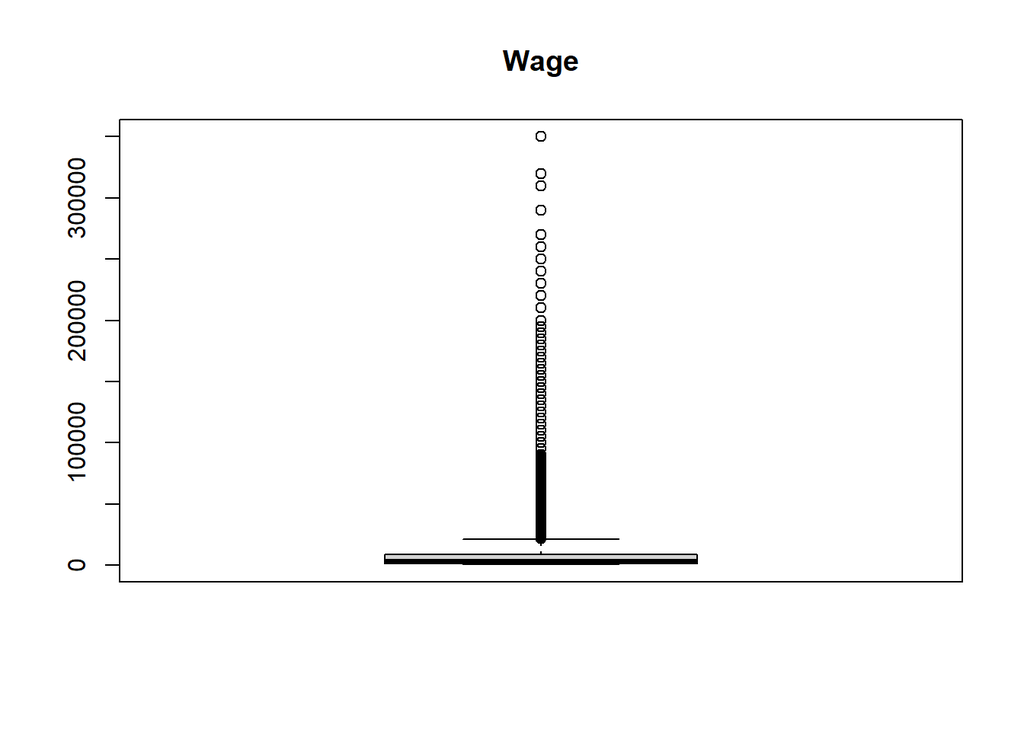

```r
boxplot(players$wage_eur,
        names = "Wage",
        main = "Wage")
```

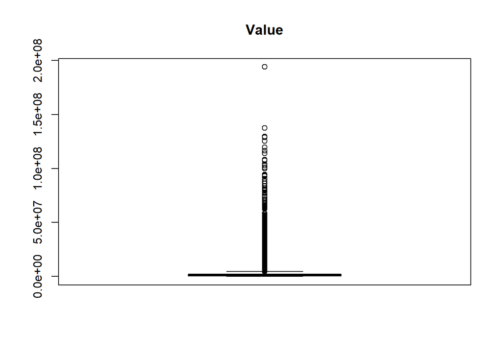

```r
boxplot(players$value_eur,
        names = "Value",
        main = "Value")
```

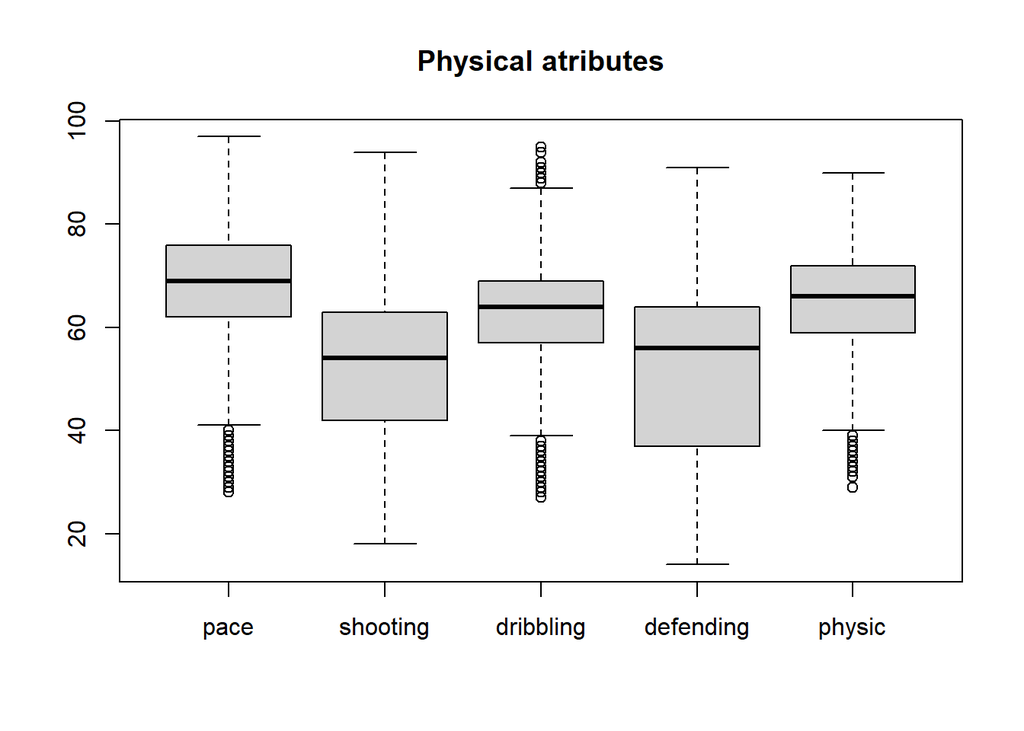

```r
boxplot(players$pace, players$shooting, players$dribbling, players$defending, players$physic,
        names = c("pace", "shooting", "dribbling", "defending", "physic"),
        main = "Physical atributes")
```

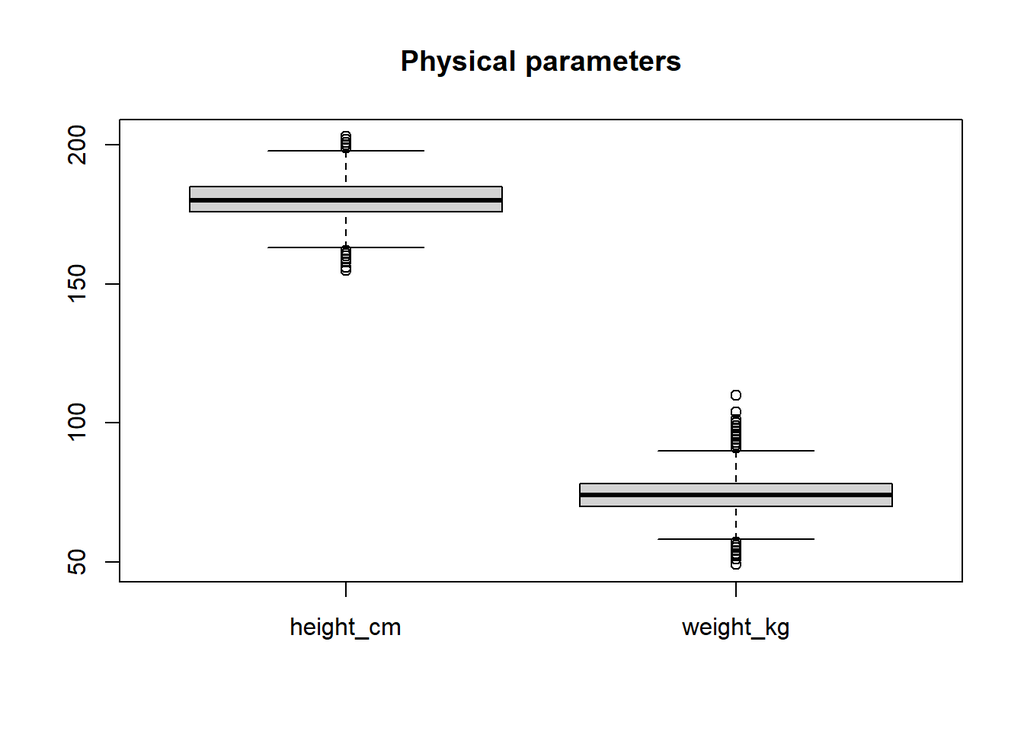

```r
boxplot(players$height_cm, players$weight_kg,
        names = c("height_cm", "weight_kg"),
        main = "Physical parameters")
```

Handling outliers

```r
Q1 <- quantile(players$pace, 0.25)
Q3 <- quantile(players$pace, 0.75)
IQR <- Q3 - Q1
players <- subset(players, players$pace >= (Q1 - 1.5 * IQR) & players$pace <= (Q3 + 1.5 * IQR))

Q1 <- quantile(players$dribbling, 0.25)
Q3 <- quantile(players$dribbling, 0.75)
IQR <- Q3 - Q1
players <- subset(players, players$dribbling >= (Q1 - 1.5 * IQR) & players$dribbling <= (Q3 + 1.5 * IQR))

Q1 <- quantile(players$physic, 0.25)
Q3 <- quantile(players$physic, 0.75)
IQR <- Q3 - Q1
players <- subset(players, players$physic >= (Q1 - 1.5 * IQR) & players$physic <= (Q3 + 1.5 * IQR))

Q1 <- quantile(players$weight_kg, 0.25)
Q3 <- quantile(players$weight_kg, 0.75)
IQR <- Q3 - Q1
players <- subset(players, players$weight_kg >= (Q1 - 1.5 * IQR) & players$weight_kg <= (Q3 + 1.5 * IQR))

Q1 <- quantile(players$height_cm, 0.25)
Q3 <- quantile(players$height_cm, 0.75)
IQR <- Q3 - Q1
players <- subset(players, players$height_cm >= (Q1 - 1.5 * IQR) & players$height_cm <= (Q3 + 1.5 * IQR))
```

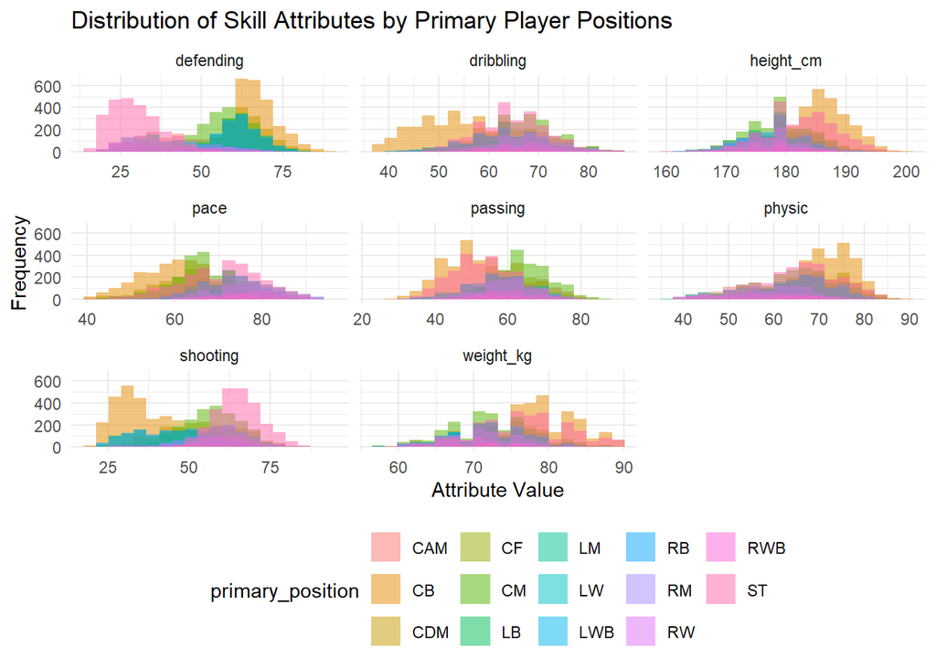

```r
players_simplified <- players %>%
  mutate(primary_position = str_split(player_positions, ",", simplify = TRUE)[,1])

# Histograms for Skill Attributes by Primary Position
players_simplified %>%
  gather(key="skill", value="value", pace, shooting, passing, dribbling, defending, physic, weight_kg, height_cm) %>%
  mutate(skill = factor(skill)) %>%
  ggplot(aes(x=value, fill=primary_position)) +
  geom_histogram(bins=20, alpha=0.5, position="identity") +
  facet_wrap(~skill, scales="free_x") +
  theme_minimal() +
  theme(legend.position="bottom") +
  labs(title="Distribution of Skill Attributes by Primary Player Positions", x="Attribute Value", y="Frequency")
```

```r
# "B" stands for defenders like "CB", "LB", "RB"
players$IsDefender <- ifelse(grepl("B", players$player_positions), 1, 0)

#
predictors <- c("pace", "shooting", "passing", "dribbling", "defending", "physic", "height_cm", "weight_kg")

# Prepare the dataset (ensure that you have no missing values in the predictors and the target variable)
classification_data <- players %>%
  select(IsDefender, all_of(predictors)) %>%
  na.omit()

# Create training and testing sets
set.seed(123) # for reproducibility
training_rows <- createDataPartition(classification_data$IsDefender, p = 0.8, list = FALSE)
train_data <- classification_data[training_rows, ]
test_data <- classification_data[-training_rows, ]
```

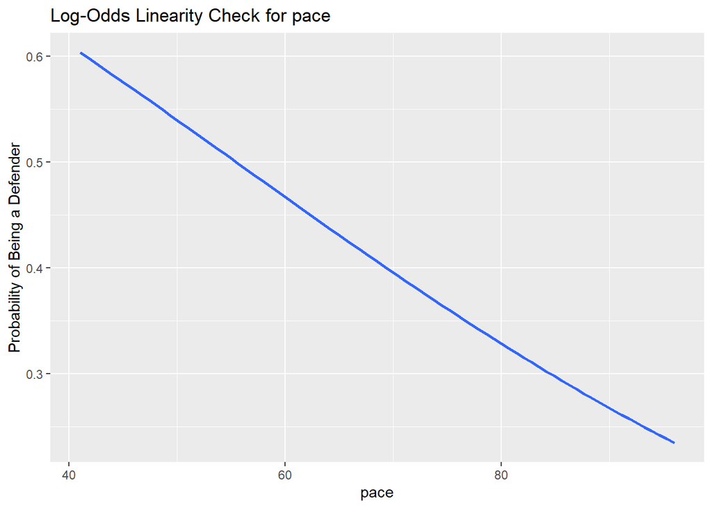

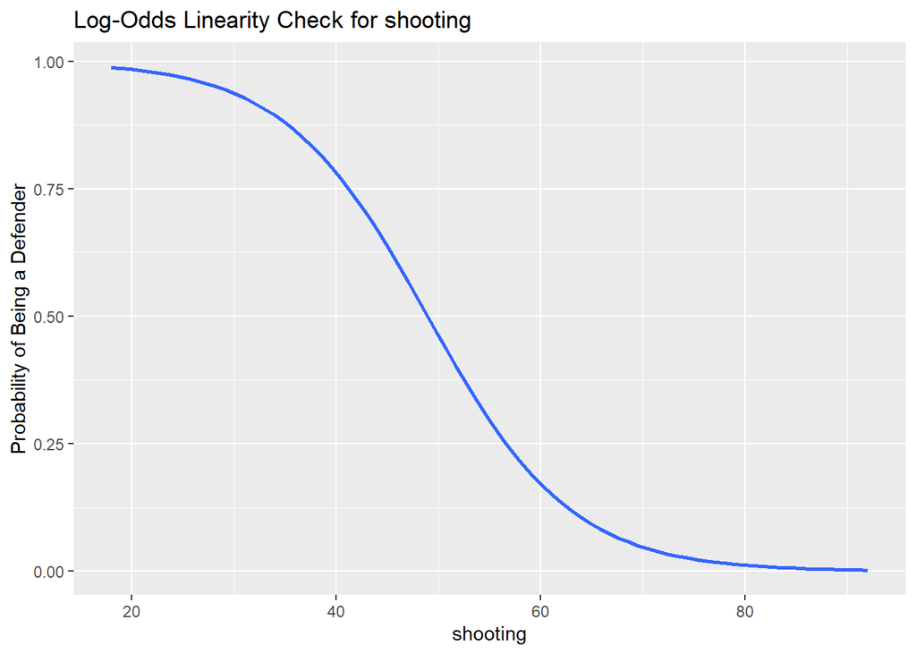

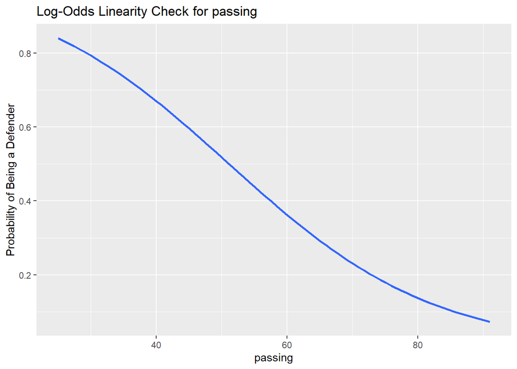

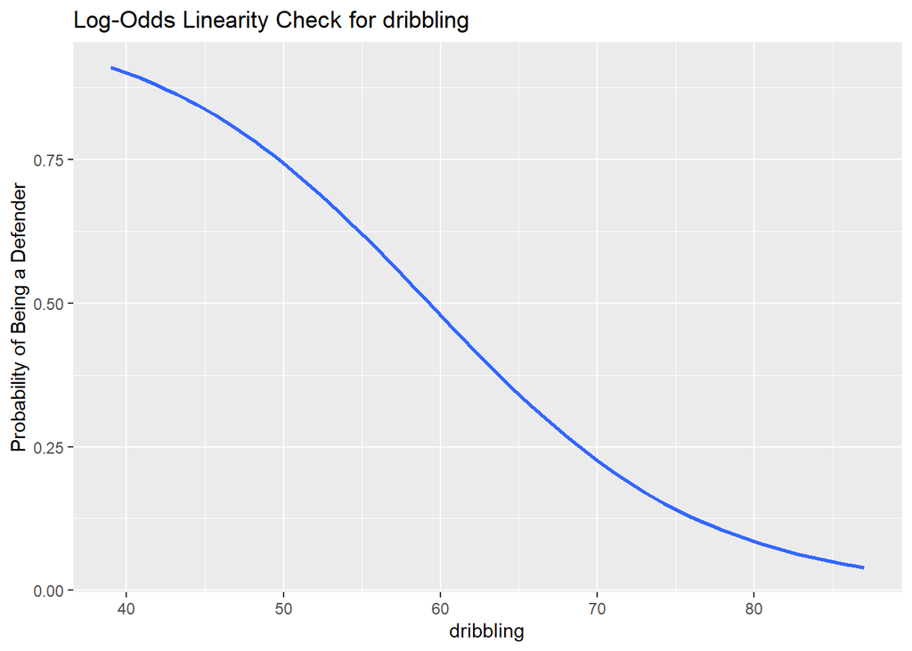

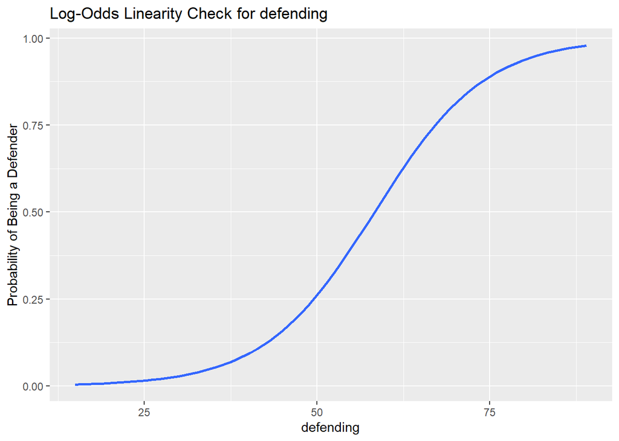

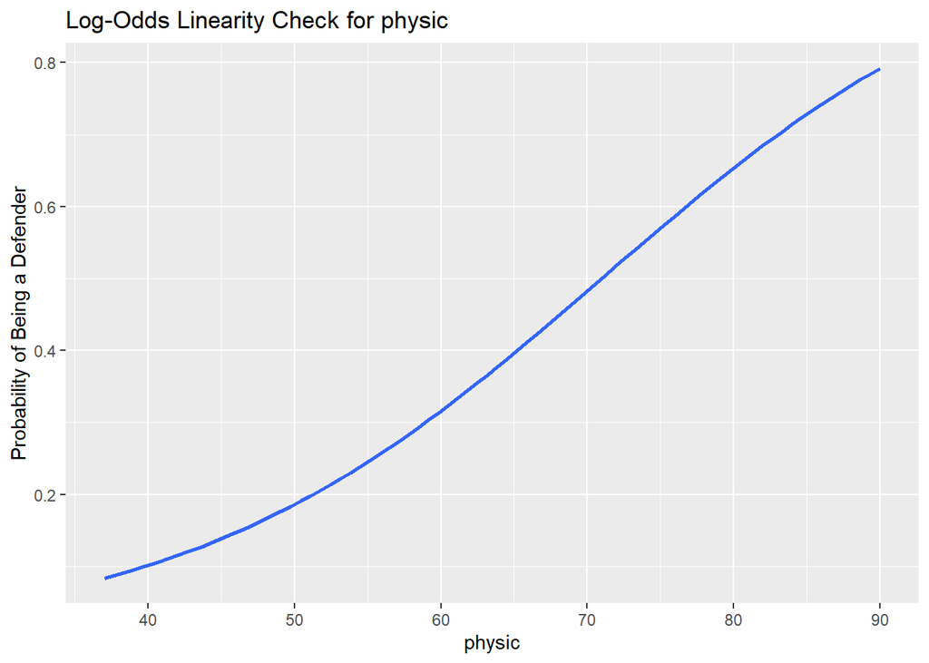

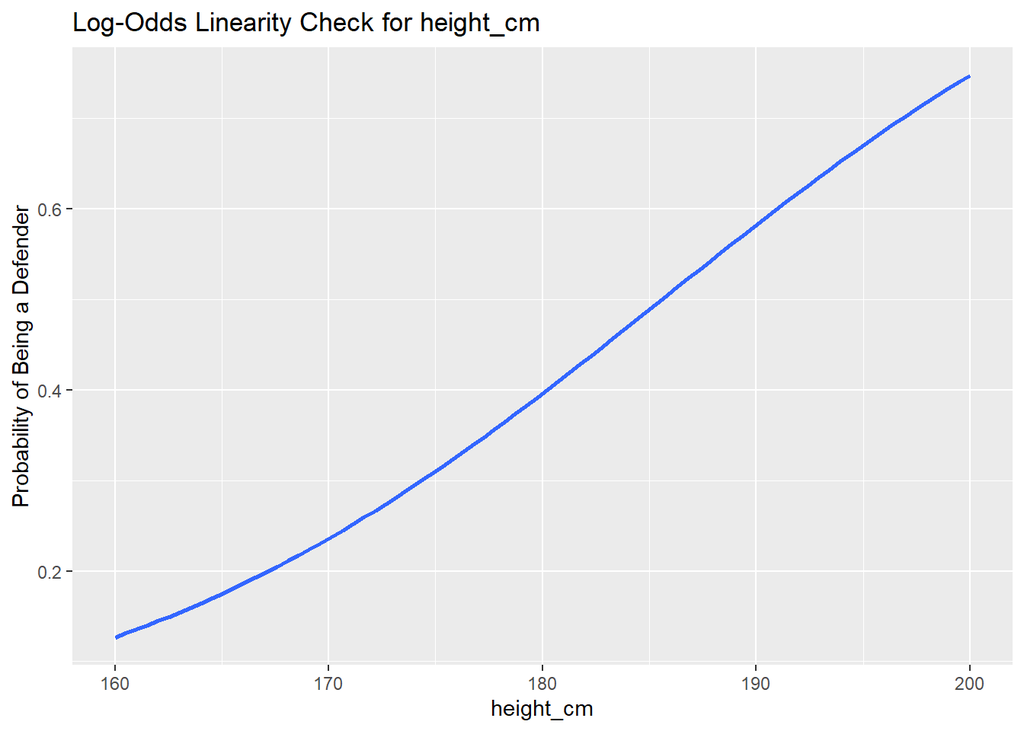

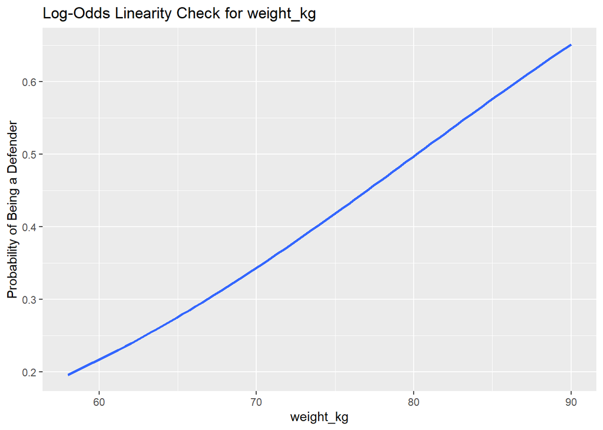

```r
continuous_vars <- c("pace", "shooting", "passing", "dribbling", "defending", "physic", "height_cm", "weight_kg")
for(var in continuous_vars) {
  p <- ggplot(train_data, aes(x = .data[[var]], y = IsDefender)) +
    geom_smooth(method = "glm", method.args = list(family = "binomial"), se = FALSE) +
    ggtitle(paste("Log-Odds Linearity Check for", var)) +
    xlab(var) +
    ylab("Probability of Being a Defender")
  print(p)
}
```

## Log-Odds Linearity Plots

These plots are checking the assumption of linearity between each predictor variable and the log-odds of the dependent variable, which is a key assumption in logistic regression. The assumption is not about linearity in the probability scale (which these plots are in), but rather in the log-odds scale. However, if the relationship looks reasonably straight on these plots, it often suggests that the relationship in the log-odds scale is also linear.

**Pace**: The plot indicates a fairly linear negative relationship between pace and the probability of being a defender. Faster players (higher pace) tend to be less likely defenders.

**Shooting**: The relationship curve starts flat at higher shooting values and then steepens as the shooting value decreases. This suggests players with lower shooting scores are much more likely to be defenders.

## Variance Inflation Factor (VIF)

VIF values provide a measure of how much the variance of the estimated regression coefficients is inflated due to multicollinearity among the predictor variables.

- **VIF Value < 5**: Generally, VIF values less than 5 indicate that multicollinearity is not severe. In your output, pace, shooting, defending, physic, height_cm, and weight_kg all have VIF values below this threshold, suggesting that they do not have concerning levels of multicollinearity.
- **VIF Value between 5 and 10**: This range indicates moderate multicollinearity. It may be a concern, but not necessarily one that will impair the model. passing and dribbling fall into this category, indicating that they have some linear association with other variables in the model but not enough to be overly problematic.
- **VIF Value > 10**: Values greater than 10 are typically considered to be indicative of high multicollinearity, requiring further attention, such as removing the variable, combining it with another variable, or using dimensionality reduction techniques.

```r
# Calculate VIF
vif_model <- vif(glm(IsDefender ~ ., data = train_data, family = "binomial"))
print(vif_model)
```

```
##      pace  shooting   passing dribbling defending    physic height_cm weight_kg
##  1.984926  2.873996  5.817949  5.504088  3.093941  2.514870  2.107950  2.331659
```

In summary, the plots show that some of the predictor variables have a non-linear relationship with the probability of being a defender. This might require transforming these variables or including them in a non-linear fashion in the logistic regression model. The VIF results mostly indicate acceptable levels of multicollinearity, except for passing and dribbling, which show moderate multicollinearity and might warrant closer inspection or remedial measures.